# Unsupervised Learning: Trade&Ahead

**Marks: 60**

### Context

The stock market has consistently proven to be a good place to invest in and save for the future. There are a lot of compelling reasons to invest in stocks. It can help in fighting inflation, create wealth, and also provides some tax benefits. Good steady returns on investments over a long period of time can also grow a lot more than seems possible. Also, thanks to the power of compound interest, the earlier one starts investing, the larger the corpus one can have for retirement. Overall, investing in stocks can help meet life's financial aspirations.

It is important to maintain a diversified portfolio when investing in stocks in order to maximise earnings under any market condition. Having a diversified portfolio tends to yield higher returns and face lower risk by tempering potential losses when the market is down. It is often easy to get lost in a sea of financial metrics to analyze while determining the worth of a stock, and doing the same for a multitude of stocks to identify the right picks for an individual can be a tedious task. By doing a cluster analysis, one can identify stocks that exhibit similar characteristics and ones which exhibit minimum correlation. This will help investors better analyze stocks across different market segments and help protect against risks that could make the portfolio vulnerable to losses.

### Objective

Trade&Ahead is a financial consultancy firm who provide their customers with personalized investment strategies. They have hired you as a Data Scientist and provided you with data comprising stock price and some financial indicators for a few companies listed under the New York Stock Exchange. They have assigned you the tasks of analyzing the data, grouping the stocks based on the attributes provided, and sharing insights about the characteristics of each group.

### Data Dictionary

- Ticker Symbol: An abbreviation used to uniquely identify publicly traded shares of a particular stock on a particular stock market
- Company: Name of the company
- GICS Sector: The specific economic sector assigned to a company by the Global Industry Classification Standard (GICS) that best defines its business operations
- GICS Sub Industry: The specific sub-industry group assigned to a company by the Global Industry Classification Standard (GICS) that best defines its business operations
- Current Price: Current stock price in dollars
- Price Change: Percentage change in the stock price in 13 weeks
- Volatility: Standard deviation of the stock price over the past 13 weeks
- ROE: A measure of financial performance calculated by dividing net income by shareholders' equity (shareholders' equity is equal to a company's assets minus its debt)
- Cash Ratio: The ratio of a company's total reserves of cash and cash equivalents to its total current liabilities
- Net Cash Flow: The difference between a company's cash inflows and outflows (in dollars)
- Net Income: Revenues minus expenses, interest, and taxes (in dollars)
- Earnings Per Share: Company's net profit divided by the number of common shares it has outstanding (in dollars)
- Estimated Shares Outstanding: Company's stock currently held by all its shareholders
- P/E Ratio: Ratio of the company's current stock price to the earnings per share
- P/B Ratio: Ratio of the company's stock price per share by its book value per share (book value of a company is the net difference between that company's total assets and total liabilities)

## Problem Definition

1. Analyze the data provided
2. Group the stocks using the attributes provided
3. Share insights about each of the groups so created

## Importing necessary libraries and data

```python
# this will help in making the Python code more structured automatically
%load_ext nb_black

# Libraries to help with reading and manipulating data
import numpy as np
import pandas as pd

# Libraries to help with data visualization
import matplotlib.pyplot as plt
import seaborn as sns

sns.set_theme(style="darkgrid")

# Removes the limit for the number of displayed columns
pd.set_option("display.max_columns", None)
# Sets the limit for the number of displayed rows
pd.set_option("display.max_rows", 200)

# to scale the data using z-score
from sklearn.preprocessing import StandardScaler

# to compute distances
from scipy.spatial.distance import cdist, pdist

# to perform k-means clustering and compute silhouette scores
from sklearn.cluster import KMeans
from sklearn.metrics import silhouette_score

# to visualize the elbow curve and silhouette scores
from yellowbrick.cluster import KElbowVisualizer, SilhouetteVisualizer

# to perform hierarchical clustering, compute cophenetic correlation, and create dendrograms
from sklearn.cluster import AgglomerativeClustering
from scipy.cluster.hierarchy import dendrogram, linkage, cophenet

# To suppress scientific notations
pd.set_option("display.float_format", lambda x: f"{x:,.2f}")

# to suppress warnings
import warnings

warnings.filterwarnings("ignore")
```

## Data Overview

- Observations
- Sanity checks

```python
# Import the Trade & Ahead dataset
data = pd.read_csv("C:\\Users\\Tayo Adeyo\\Downloads\\Module7_week2\\stock_data.csv")
```

```python
# creating a copy of the data so as not to make changes to the original datasets.
df = data.copy()
```

```python
# Checking the shape of the datasets
df.shape
```

```
(340, 15)
```

```python
# Check the first 10 lines of the dataset to make sure it is properly loaded
df.head(10)
```

|  | Ticker Symbol | Security | GICS Sector | GICS Sub Industry | Current Price | Price Change | Volatility | ROE | Cash Ratio | Net Cash Flow | Net Income | Earnings Per Share | Estimated Shares Outstanding | P/E Ratio | P/B Ratio |
| --- | --- | --- | --- | --- | --- | --- | --- | --- | --- | --- | --- | --- | --- | --- | --- |
| 0 | AAL | American Airlines Group | Industrials | Airlines | 42.35 | 10.00 | 1.69 | 135 | 51 | -604000000 | 7610000000 | 11.39 | 668,129,938.50 | 3.72 | -8.78 |
| 1 | ABBV | AbbVie | Health Care | Pharmaceuticals | 59.24 | 8.34 | 2.20 | 130 | 77 | 51000000 | 5144000000 | 3.15 | 1,633,015,873.00 | 18.81 | -8.75 |
| 2 | ABT | Abbott Laboratories | Health Care | Health Care Equipment | 44.91 | 11.30 | 1.27 | 21 | 67 | 938000000 | 4423000000 | 2.94 | 1,504,421,769.00 | 15.28 | -0.39 |
| 3 | ADBE | Adobe Systems Inc | Information Technology | Application Software | 93.94 | 13.98 | 1.36 | 9 | 180 | -240840000 | 629551000 | 1.26 | 499,643,650.80 | 74.56 | 4.20 |
| 4 | ADI | Analog Devices, Inc. | Information Technology | Semiconductors | 55.32 | -1.83 | 1.70 | 14 | 272 | 315120000 | 696878000 | 0.31 | 2,247,993,548.00 | 178.45 | 1.06 |
| 5 | ADM | Archer-Daniels-Midland Co | Consumer Staples | Agricultural Products | 36.68 | -12.02 | 1.52 | 10 | 49 | -189000000 | 1849000000 | 2.99 | 618,394,648.80 | 12.27 | 7.50 |
| 6 | ADS | Alliance Data Systems | Information Technology | Data Processing & Outsourced Services | 276.57 | 6.19 | 1.12 | 30 | 25 | 90885000 | 596541000 | 8.91 | 66,951,851.85 | 31.04 | 129.06 |
| 7 | AEE | Ameren Corp | Utilities | MultiUtilities | 43.23 | 2.17 | 1.12 | 9 | 14 | 287000000 | 636000000 | 2.60 | 244,615,384.60 | 16.63 | -0.72 |
| 8 | AEP | American Electric Power | Utilities | Electric Utilities | 58.27 | 2.37 | 1.07 | 11 | 9 | 13900000 | 2052300000 | 3.13 | 421,897,810.20 | 18.46 | -3.02 |
| 9 | AFL | AFLAC Inc | Financials | Life & Health Insurance | 59.90 | 3.03 | 1.05 | 14 | 99 | -308000000 | 2533000000 | 5.88 | 430,782,312.90 | 10.19 | -1.88 |

```python
# Checking the data types of the columns for the dataset
df.info()
```

```
<class 'pandas.core.frame.DataFrame'>
RangeIndex: 340 entries, 0 to 339
Data columns (total 15 columns):
 #   Column                        Non-Null Count  Dtype
---  ------                        --------------  -----
 0   Ticker Symbol                 340 non-null    object
 1   Security                      340 non-null    object
 2   GICS Sector                   340 non-null    object
 3   GICS Sub Industry             340 non-null    object
 4   Current Price                 340 non-null    float64
 5   Price Change                  340 non-null    float64
 6   Volatility                    340 non-null    float64
 7   ROE                           340 non-null    int64
 8   Cash Ratio                    340 non-null    int64
 9   Net Cash Flow                 340 non-null    int64
 10  Net Income                    340 non-null    int64
 11  Earnings Per Share            340 non-null    float64
 12  Estimated Shares Outstanding  340 non-null    float64
 13  P/E Ratio                     340 non-null    float64
 14  P/B Ratio                     340 non-null    float64
dtypes: float64(7), int64(4), object(4)
memory usage: 40.0+ KB
```

**There are eleven columns with numeric data types (interger or float) and the remaining four are object data types**

```python
# Checking for missing entries in the dataset
df.isnull().sum()
```

```
Ticker Symbol                   0
Security                        0
GICS Sector                     0
GICS Sub Industry               0
Current Price                   0
Price Change                    0
Volatility                      0
ROE                             0
Cash Ratio                      0
Net Cash Flow                   0
Net Income                      0
Earnings Per Share              0
Estimated Shares Outstanding    0
P/E Ratio                       0
P/B Ratio                       0
dtype: int64
```

**There are no missing entries in the dataset**

```python
# Checking for duplicate entries in the dataset
df.duplicated().value_counts()
```

```
False    340
dtype: int64
```

**There are no duplicate entries in the dataset**

```python
# Statistical summary of the numerical columns of the dataset
df.describe().T
```

|  | count | mean | std | min | 25% | 50% | 75% | max |
| --- | --- | --- | --- | --- | --- | --- | --- | --- |
| Current Price | 340.00 | 80.86 | 98.06 | 4.50 | 38.55 | 59.70 | 92.88 | 1,274.95 |
| Price Change | 340.00 | 4.08 | 12.01 | -47.13 | -0.94 | 4.82 | 10.70 | 55.05 |
| Volatility | 340.00 | 1.53 | 0.59 | 0.73 | 1.13 | 1.39 | 1.70 | 4.58 |
| ROE | 340.00 | 39.60 | 96.55 | 1.00 | 9.75 | 15.00 | 27.00 | 917.00 |
| Cash Ratio | 340.00 | 70.02 | 90.42 | 0.00 | 18.00 | 47.00 | 99.00 | 958.00 |
| Net Cash Flow | 340.00 | 55,537,620.59 | 1,946,365,312.18 | -11,208,000,000.00 | -193,906,500.00 | 2,098,000.00 | 169,810,750.00 | 20,764,000,000.00 |
| Net Income | 340.00 | 1,494,384,602.94 | 3,940,150,279.33 | -23,528,000,000.00 | 352,301,250.00 | 707,336,000.00 | 1,899,000,000.00 | 24,442,000,000.00 |
| Earnings Per Share | 340.00 | 2.78 | 6.59 | -61.20 | 1.56 | 2.90 | 4.62 | 50.09 |
| Estimated Shares Outstanding | 340.00 | 577,028,337.75 | 845,849,595.42 | 27,672,156.86 | 158,848,216.10 | 309,675,137.80 | 573,117,457.32 | 6,159,292,035.00 |
| P/E Ratio | 340.00 | 32.61 | 44.35 | 2.94 | 15.04 | 20.82 | 31.76 | 528.04 |
| P/B Ratio | 340.00 | -1.72 | 13.97 | -76.12 | -4.35 | -1.07 | 3.92 | 129.06 |

#### Observations

- The average Current price of listed stocks is 80.86 dollars, with a median of 59.70 dollars, maximum current price of stocks listed is 1274.95 dollars.
- Maximum percentage change in price for the stocks over the last 13 weeks is 55.05%, while the average is 4.08%.
- average volatility of the listed stocks, that is, the standard deviation of the price over the last 13 weeks is 1.53, the median is 1.39 while the maximum volatility is 4.58
- Average return on equity, ROE is 39.60, while the median and the maximum is 15.00 and 917.00 respectively.
- Average cash ratio for the listed stocks is 70.02, with a median of 47.00 and a maximum of 958.00
- Maximum and Minimum Net Cash Flow for the listed stocks stands at 20.764 billion dollars and -11.208 billion dollars respectively, while the average and median is at 55.538 million dollars and 2.098 million dollars respectively.
- Maximum and Minimum Net Income stands at 24.442 billion dollars and -23,528 billion dollars respectively, while the average and median is at 1.494 billion dollars and 707.336 million dollars respectively.
- Average earnings per share is 2.78, median is 2.90 and the maximum is 50.09
- Maximum and Minimum Estimated Shares outstanding stands at 6.159 billion and 27,672 million respectively, while the average and median is at 577.028 million and 309.675 million respectively.
- The maximum ratio of the stock price to earnings per share, P/E ratio stands at 528.04, minimum at 2.94, average and median at 32.61 and 20.82 respectively.
- The maximum ratio of the stock price to book value per share, P/B ratio stands at 129.06, minimum at -76.12, average and median at -1.72 and -1.07 respectively.

```python
# Statistical summary of the categorical columns of the dataset
df.describe(include="object").T
```

|  | count | unique | top | freq |
| --- | --- | --- | --- | --- |
| Ticker Symbol | 340 | 340 | AAL | 1 |
| Security | 340 | 340 | American Airlines Group | 1 |
| GICS Sector | 340 | 11 | Industrials | 53 |
| GICS Sub Industry | 340 | 104 | Oil & Gas Exploration & Production | 16 |

- There are 4 categorical columns, namely: Ticker Symbol, Security, GICS Sector, and GICS Sub Industry.
- The Ticker Symbol is just an abbreviation to describe the Security (the stock name), and will not be needed in our analysis, so we can drop it

```python
# Dropping Ticker Symbol
df.drop("Ticker Symbol", axis=1, inplace=True)
```

```python
# Statistical summary of the categorical columns of the dataset
df.describe(include="object").T
```

|  | count | unique | top | freq |
| --- | --- | --- | --- | --- |
| Security | 340 | 340 | American Airlines Group | 1 |
| GICS Sector | 340 | 11 | Industrials | 53 |
| GICS Sub Industry | 340 | 104 | Oil & Gas Exploration & Production | 16 |

- There is a total of 11 unique Industry classifications (GICS Sector) and a total of 104 industry subsectors (GICS Sub Industry)in the dataset.
- The Industrials sector is the most common Industry classification, while Oil & Gas Exploration & Production is the most common subsector.

```python
df["GICS Sector"].value_counts()
```

```
Industrials                    53
Financials                     49
Health Care                    40
Consumer Discretionary         40
Information Technology         33
Energy                         30
Real Estate                    27
Utilities                      24
Materials                      20
Consumer Staples               19
Telecommunications Services     5
Name: GICS Sector, dtype: int64
```

```python
df["GICS Sub Industry"].value_counts().head(10)
```

```
Oil & Gas Exploration & Production    16
REITs                                 14
Industrial Conglomerates              14
Electric Utilities                    12
Internet Software & Services          12
Health Care Equipment                 11
MultiUtilities                        11
Banks                                 10
Property & Casualty Insurance          8
Diversified Financial Services         7
Name: GICS Sub Industry, dtype: int64
```

## Exploratory Data Analysis (EDA)

- EDA is an important part of any project involving data.
- It is important to investigate and understand the data better before building a model with it.
- A few questions have been mentioned below which will help you approach the analysis in the right manner and generate insights from the data.
- A thorough analysis of the data, in addition to the questions mentioned below, should be done.

```python
# function to plot a boxplot and a histogram along the same scale.


def histogram_boxplot(df, feature, figsize=(12, 7), kde=False, bins=None):
    """
    Boxplot and histogram combined

    data: dataframe
    feature: dataframe column
    figsize: size of figure (default (12,7))
    kde: whether to the show density curve (default False)
    bins: number of bins for histogram (default None)
    """
    f2, (ax_box2, ax_hist2) = plt.subplots(
        nrows=2,  # Number of rows of the subplot grid= 2
        sharex=True,  # x-axis will be shared among all subplots
        gridspec_kw={"height_ratios": (0.25, 0.75)},
        figsize=figsize,
    )  # creating the 2 subplots
    sns.boxplot(
        data=df, x=feature, ax=ax_box2, showmeans=True, color="violet"
    )  # boxplot will be created and a star will indicate the mean value of the column
    sns.histplot(
        data=df, x=feature, kde=kde, ax=ax_hist2, bins=bins, palette="winter"
    ) if bins else sns.histplot(
        data=df, x=feature, kde=kde, ax=ax_hist2
    )  # For histogram
    ax_hist2.axvline(
        df[feature].mean(), color="green", linestyle="--"
    )  # Add mean to the histogram
    ax_hist2.axvline(
        df[feature].median(), color="black", linestyle="-"
    )  # Add median to the histogram
```

```python
# function to create labeled barplots


def labeled_barplot(data, feature, perc=False, n=None):
    """
    Barplot with percentage at the top

    data: dataframe
    feature: dataframe column
    perc: whether to display percentages instead of count (default is False)
    n: displays the top n category levels (default is None, i.e., display all levels)
    """

    total = len(data[feature])  # length of the column
    count = data[feature].nunique()
    if n is None:
        plt.figure(figsize=(count + 2, 5))
    else:
        plt.figure(figsize=(n + 2, 5))

    plt.xticks(rotation=90, fontsize=12)
    ax = sns.countplot(
        data=data,
        x=feature,
        palette="Paired",
        order=data[feature].value_counts().index[:n].sort_values(),
    )

    for p in ax.patches:
        if perc == True:
            label = "{:.1f}%".format(
                100 * p.get_height() / total
            )  # percentage of each class of the category
        else:
            label = p.get_height()  # count of each level of the category

        x = p.get_x() + p.get_width() / 2  # width of the plot
        y = p.get_height()  # height of the plot

        ax.annotate(
            label,
            (x, y),
            ha="center",
            va="center",
            size=12,
            xytext=(0, 5),
            textcoords="offset points",
        )  # annotate the percentage

    plt.show()  # show the plot
```

### Univariate Analysis

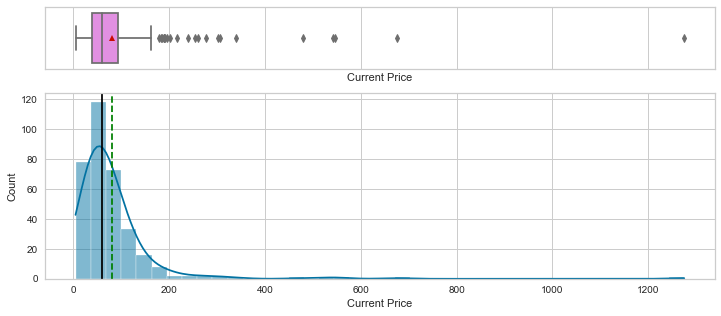

```python
histogram_boxplot(df, "Current Price", bins=40, kde=True, figsize=(12, 5))
```

### Question 1

**What does the distribution of stock prices look like?**

- The distribution for the Current price is right skewed with many outliers to the right

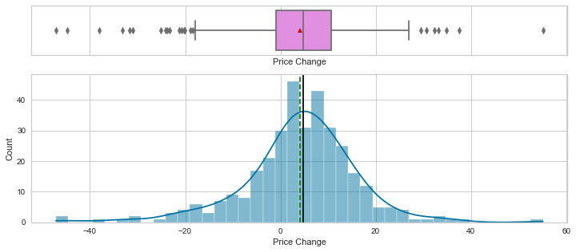

```python
histogram_boxplot(df, "Price Change", bins=40, kde=True, figsize=(12, 5))
```

- The didtribution for Price Change is almost normal with outliers to both left and right

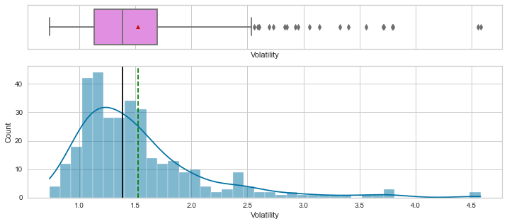

```python
histogram_boxplot(df, "Volatility", bins=40, kde=True, figsize=(12, 5))
```

- The distribution for Volatility right skewed with outliers to the right

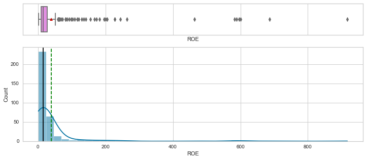

```python
histogram_boxplot(df, "ROE", bins=40, kde=True, figsize=(12, 5))
```

- The distribution for ROE is right skewed with outliers to the right

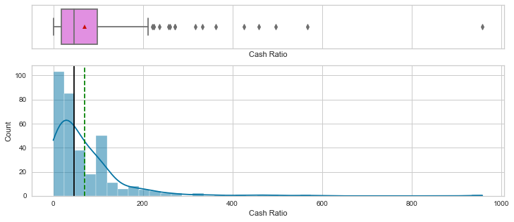

```python
histogram_boxplot(df, "Cash Ratio", bins=40, kde=True, figsize=(12, 5))
```

- The distribution for Cash Ratio is right skewed with outliers to the right

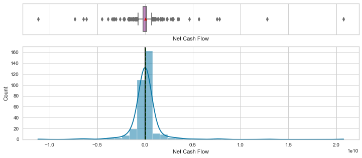

```python
histogram_boxplot(df, "Net Cash Flow", bins=40, kde=True, figsize=(12, 5))
```

- The distribution for Net Cash Flow has a normal distribution but with otliers to both right and left

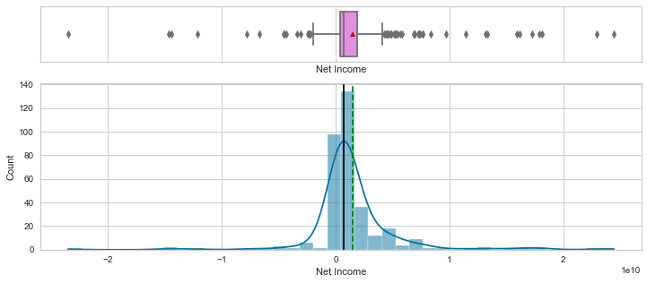

```python
histogram_boxplot(df, "Net Income", bins=40, kde=True, figsize=(12, 5))
```

- The distribution for Net Income is right skewed with outliers to both left and right

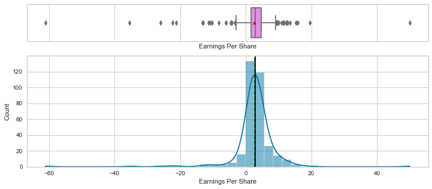

```python
histogram_boxplot(df, "Earnings Per Share", bins=40, kde=True, figsize=(12, 5))
```

- The distribution for Earnings per share is normal with outliers to both left and right

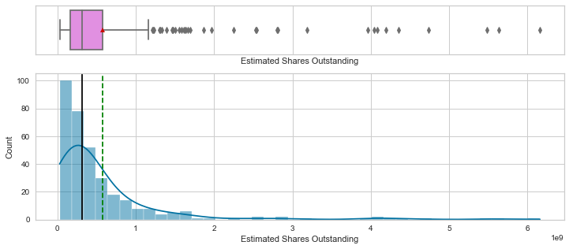

```python
histogram_boxplot(
    df, "Estimated Shares Outstanding", bins=40, kde=True, figsize=(12, 5)
)
```

- The distribution for Estimated Shares Outstanding is right skewed with outliers to the right

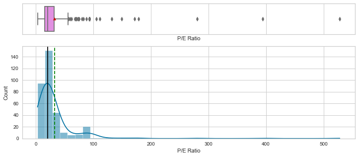

```python
histogram_boxplot(df, "P/E Ratio", bins=40, kde=True, figsize=(12, 5))
```

- The distribution for P/E ratio is right skewed with outliers to the right

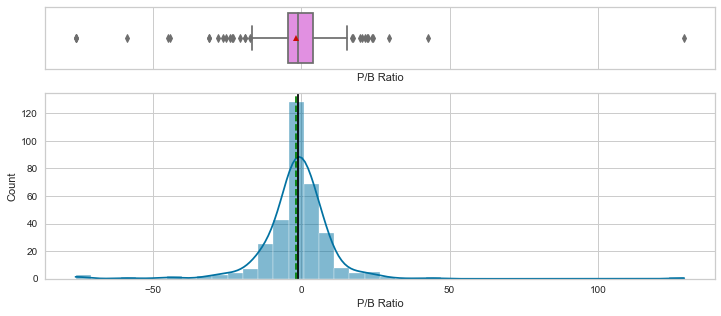

```python
histogram_boxplot(df, "P/B Ratio", bins=40, kde=True, figsize=(12, 5))
```

- The distribution for P/B Ratio is almost normal with outliers to both left and right

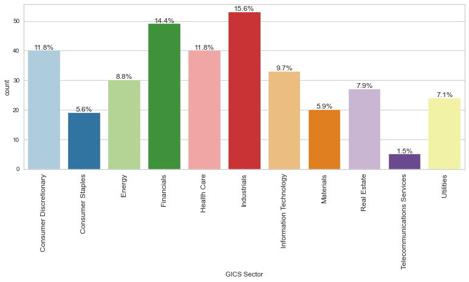

```python
labeled_barplot(df, "GICS Sector", perc=True)
```

- More than half of the listed securities came from four of the GICS Sectors with the Industrials sector being responsible for 15.6% of the listed stocks, followed by the Financials sector at 14.4%. The Health Care and Consumer Discretionary sectors are each responsible for 11.8% of the listecd securities.

[figure not shown]

```python
labeled_barplot(df, "GICS Sub Industry", perc=True)
```

```python
df["GICS Sub Industry"].value_counts().head(10)
```

```
Oil & Gas Exploration & Production    16
REITs                                 14
Industrial Conglomerates              14
Electric Utilities                    12
Internet Software & Services          12
Health Care Equipment                 11
MultiUtilities                        11
Banks                                 10
Property & Casualty Insurance          8
Diversified Financial Services         7
Name: GICS Sub Industry, dtype: int64
```

- Ten out of the 104 subsectors are responsible for 115 out of the 340 (more than 33%) of the listed securities.

### Bivariate Ananalysis

```python
# create the list of columns with numerical variables
num_columns = df.select_dtypes(include=np.number).columns.tolist()
```

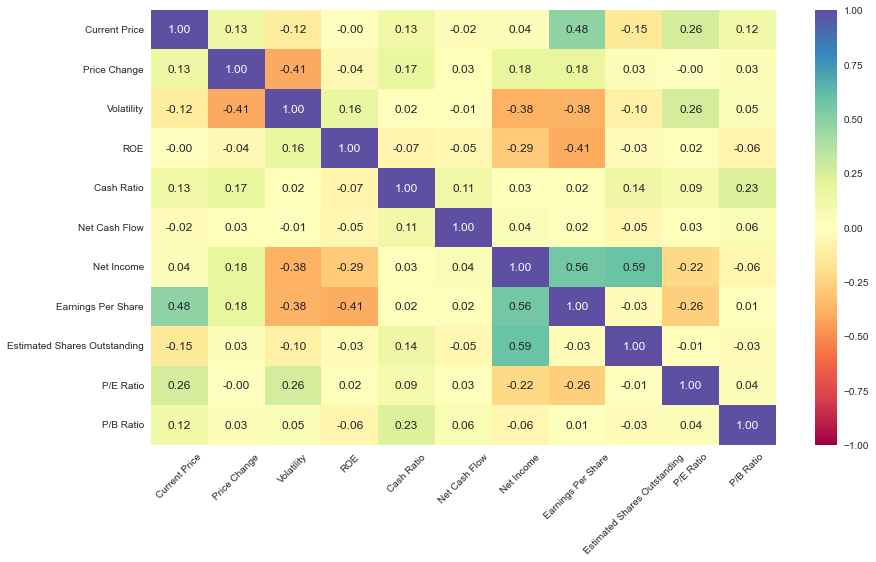

```python
# Plot the correlation map for the numerical variables

plt.figure(figsize=(14, 8))
sns.heatmap(
    df[num_columns].corr(), annot=True, vmin=-1, vmax=1, fmt=".2f", cmap="Spectral"
)
plt.xticks(rotation=45)
plt.show()
```

### Question 3

**How are the different variables correlated with each other?**

- Some variables are moderately correlated with one another. I'm using +/- 0.35 to 0.60 as moderate correlation.
1. Net Income is positively correlated with Earnings per share and Estimated shares outstanding.
2. Current Price is also positively correlated with Earnings per share
3. Return on Equity ROE is negatively correlated with Earnings per share
4. Volatiliy is negatively correlated with price change, Net Income and Earnings per share.

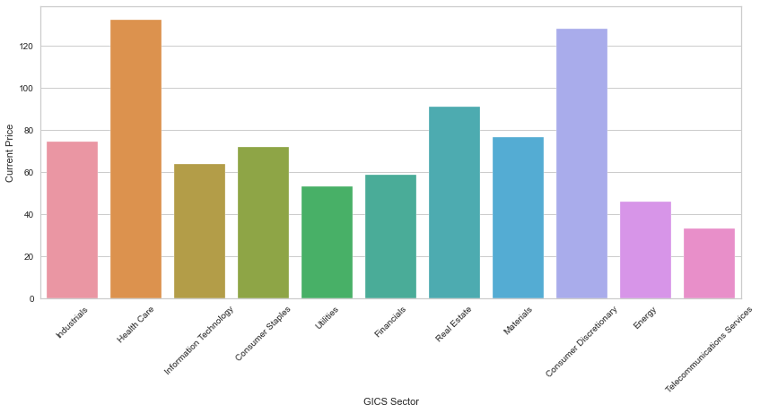

```python
plt.figure(figsize=(14, 6))
sns.barplot(
    data=df, y="Current Price", x="GICS Sector", ci=False
)  ## Complete the code to choose the right variables
plt.xticks(rotation=45)
plt.show()
```

- The Health care Sector has the highest average current price amongst the listed equities. Its closely followed by the Consumer discretionary sector. Telecommunication services and Energy sector has the lowest average Current price.

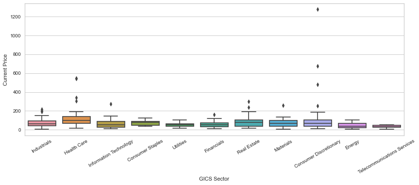

```python
plt.figure(figsize=(14, 5))
sns.boxplot(data=df, y="Current Price", x="GICS Sector")
plt.xticks(rotation=30)
plt.show()
```

- Consumer Discretionary, Health Care and the Real estate sectors are responsible for most of the outliers seen in the Current price of the listings. Health care has the highest average current price

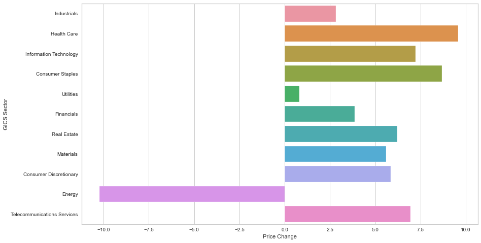

```python
plt.figure(figsize=(14, 8))
sns.barplot(
    data=df, x="Price Change", y="GICS Sector", ci=False
)  ## Complete the code to choose the right variables
plt.show()
```

- Health care and Consumer staples sectors have the highest average Price change per quartyer. The Energy sector has a large negative value of price change, which is an indication of falling prices in the last quarter.

```python
df.groupby("GICS Sector")["Price Change"].mean().sort_values()
```

```
GICS Sector
Energy                        -10.23
Utilities                       0.80
Industrials                     2.83
Financials                      3.87
Materials                       5.59
Consumer Discretionary          5.85
Real Estate                     6.21
Telecommunications Services     6.96
Information Technology          7.22
Consumer Staples                8.68
Health Care                     9.59
Name: Price Change, dtype: float64
```

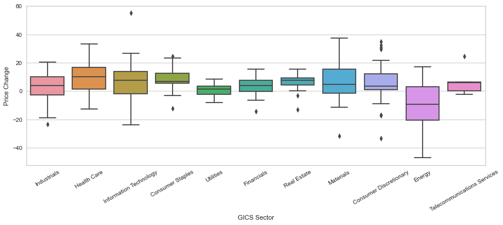

```python
plt.figure(figsize=(14, 5))
sns.boxplot(data=df, y="Price Change", x="GICS Sector")
plt.xticks(rotation=30)
plt.show()
```

- Most of the equities listed for Price Change has little or no outlier except for the Consumer Discretionary Sector that has quite a few positive and negative outliers. All the Sectors have price changes moving between positive and negative values, but only the Energy sector have an average Negative Price change for the last quarter.

### Question 2

**The stocks of which economic sector have seen the maximum price increase on average?**

- Listed Stocks from the Health Care sector have shown the maximum average price increase.

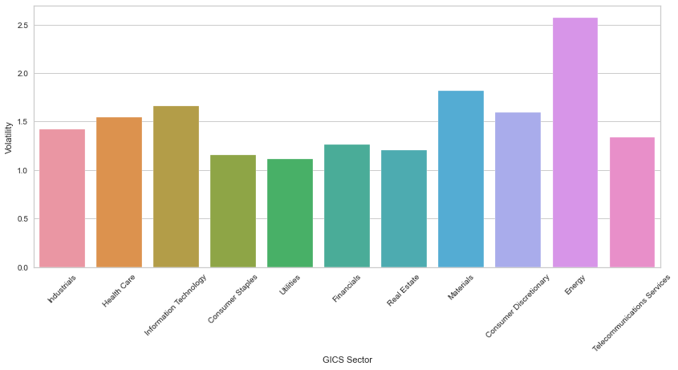

```python
plt.figure(figsize=(14, 6))
sns.barplot(
    data=df, y="Volatility", x="GICS Sector", ci=False
)  ## Complete the code to choose the right variables
plt.xticks(rotation=45)
plt.show()
```

- The Energy sector has the most volatile equities amongst those listed. It is followed by securities from the materials sector. Utilities and Consumer staples has the lowest volatility amongst the listed securies.

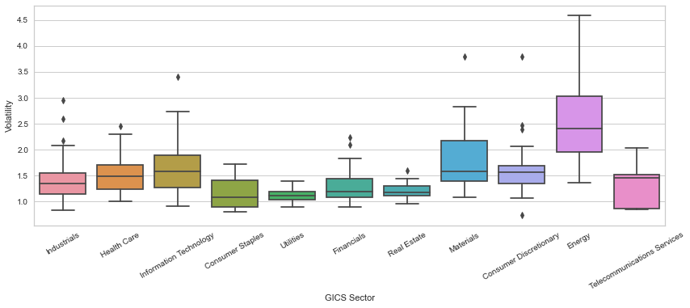

```python
plt.figure(figsize=(14, 5))
sns.boxplot(data=df, y="Volatility", x="GICS Sector")
plt.xticks(rotation=30)
plt.show()
```

- The Real Estate and Utilities sectors experienced the smallest amount of fluctuations (volatility) in prices amongst the listed equities. The Energy , Information Technology, and Materials sector experience the highest fluctuations.

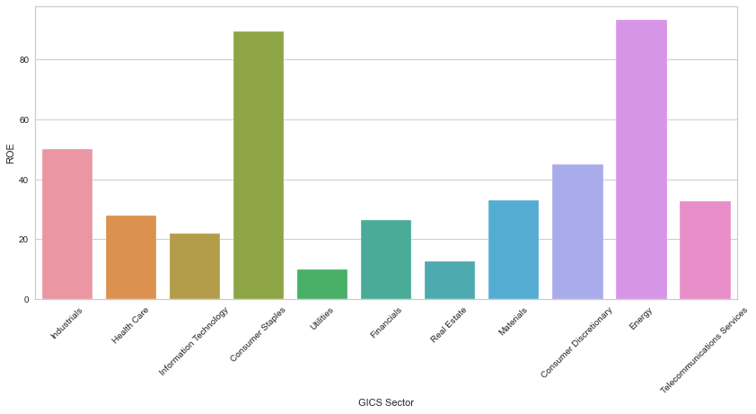

```python
plt.figure(figsize=(14, 6))
sns.barplot(
    data=df, y="ROE", x="GICS Sector", ci=False
)  ## Complete the code to choose the right variables
plt.xticks(rotation=45)
plt.show()
```

- The Energy and the Consumer staples sectors (in that order) has the highest ROE amongst the listed securities. Utilities and Real Estate has the lowest.

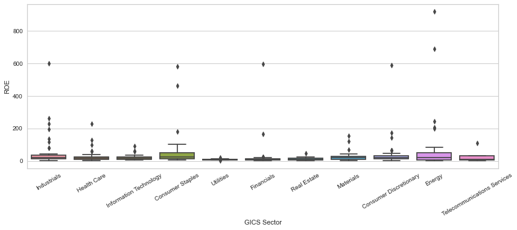

```python
plt.figure(figsize=(14, 5))
sns.boxplot(data=df, y="ROE", x="GICS Sector")
plt.xticks(rotation=30)
plt.show()
```

- The Return on Equity (ROE) for many of the equities have many outliers except for the Utilities, Real Estate and Telecommunications services that has just a few.

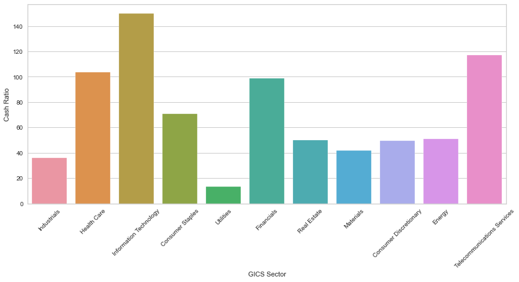

```python
plt.figure(figsize=(14, 6))
sns.barplot(
    data=df, y="Cash Ratio", x="GICS Sector", ci=False
)  ## Complete the code to choose the right variables
plt.xticks(rotation=45)
plt.show()
```

- The Information Technology and Telecommunications Services sectors have the highest cash ratio among the listed equities. The utilities and Industrials sectors have the lowest.

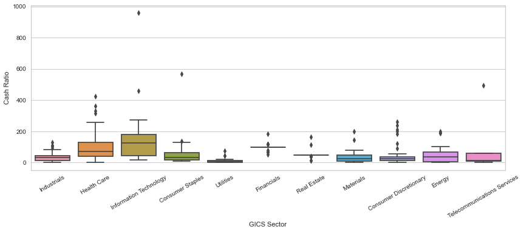

```python
plt.figure(figsize=(14, 5))
sns.boxplot(data=df, y="Cash Ratio", x="GICS Sector")
plt.xticks(rotation=30)
plt.show()
```

- Information Technology has the highest swing in their Cash Ratio with very large outliers. Utilities has the smallest swing

```python
df.groupby("GICS Sector")["Cash Ratio"].mean().sort_values(ascending=False)
```

```
GICS Sector
Information Technology        149.82
Telecommunications Services   117.00
Health Care                   103.78
Financials                     98.59
Consumer Staples               70.95
Energy                         51.13
Real Estate                    50.11
Consumer Discretionary         49.58
Materials                      41.70
Industrials                    36.19
Utilities                      13.62
Name: Cash Ratio, dtype: float64
```

### Question 4

**Cash ratio provides a measure of a company's ability to cover its short-term obligations using only cash and cash equivalents. How does the average cash ratio vary across economic sectors?**

- Securities listed under Information Technology, Telecommunications Services and Health Care sector have the highest Cash ratio amongst the listed securities, whereas securities listed under the Utilities sector have the lowest Cash Ratio, followed by those listed under the Industials and materials Sector.

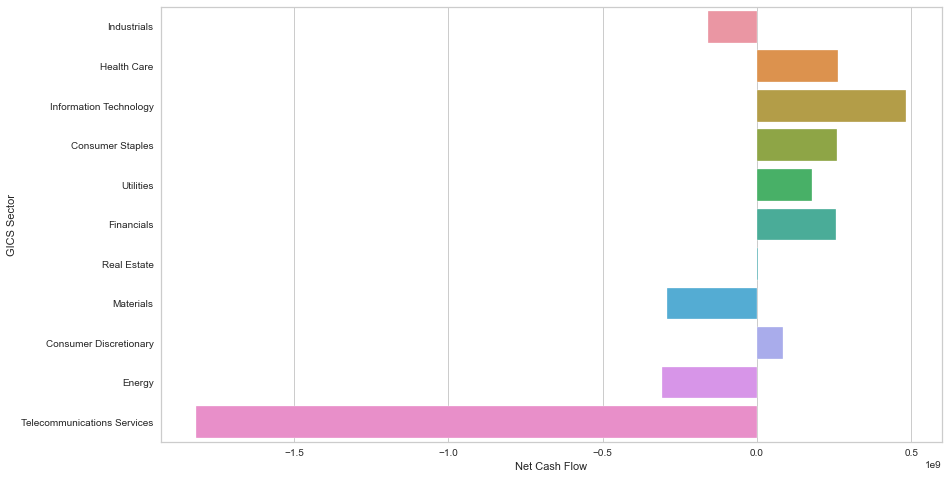

```python
plt.figure(figsize=(14, 8))
sns.barplot(
    data=df, x="Net Cash Flow", y="GICS Sector", ci=False
)  ## Complete the code to choose the right variables
plt.show()
```

- Information Technology has the highest Net cash flow amongst the listed securities. Telecommunication services seems to have a disproportionately small cash inflow compared to their cash outflows which results in their large negative Net cash flow.

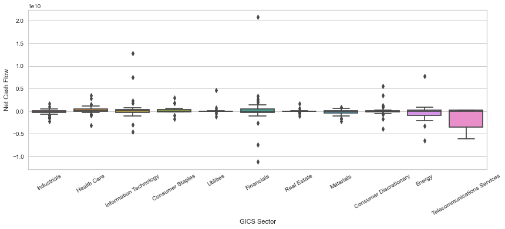

```python
plt.figure(figsize=(14, 5))
sns.boxplot(data=df, y="Net Cash Flow", x="GICS Sector")
plt.xticks(rotation=30)
plt.show()
```

- The Telecommunications Services sector has a very large and negative Net cash Flow with no outlier.

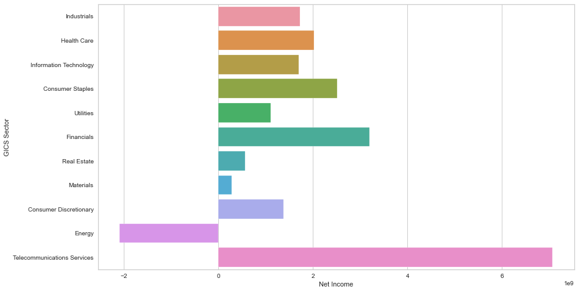

```python
plt.figure(figsize=(14, 8))
sns.barplot(
    data=df, x="Net Income", y="GICS Sector", ci=False
)  ## Complete the code to choose the right variables
plt.show()
```

- The Telecommunication Services sector has the highest Net Income amongst the listed securities. The Energy sector has a negative Net Income, which means their expenditure outstrips their revenue.

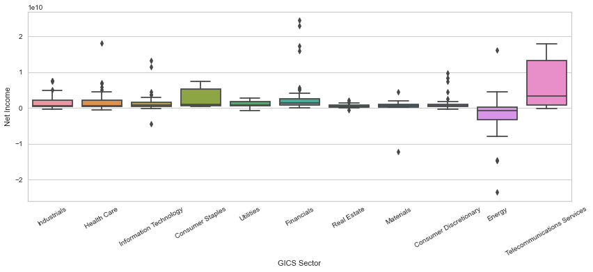

```python
plt.figure(figsize=(14, 5))
sns.boxplot(data=df, y="Net Income", x="GICS Sector")
plt.xticks(rotation=30)
plt.show()
```

- The Telecommunications Services sector has a very large positive Net Income with no outlier, same for Consumer staples, but the Energy Sector has a large Negative Net Income with both positive and negative outliers.

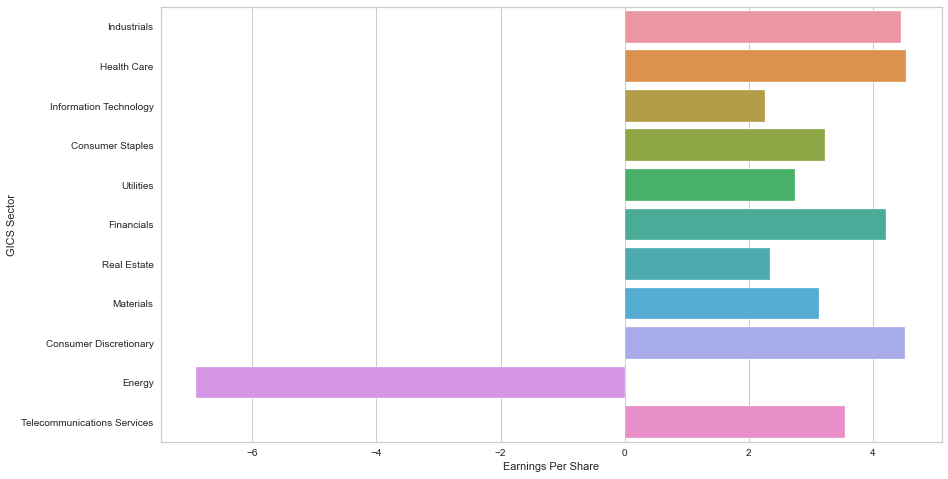

```python
plt.figure(figsize=(14, 8))
sns.barplot(
    data=df, x="Earnings Per Share", y="GICS Sector", ci=False
)  ## Complete the code to choose the right variables
plt.show()
```